### Stock Market Prediction Using Machine Learning

## Abstract

# Steps Followed

1. **Data Cleaning:**
   - Removed rows with missing values in key columns (`returns`, `sentiment_lag1`, `sentiment_lag2`).
   - Stripped any extra whitespace from column names.
2. **Feature Selection:**
   - Selected relevant features: `execution_price`, `num_trades`, `value`, `avg_trade_size`, `sentiment_lag1`, `sentiment_lag2`, `returns`.
   - Target variable: `classification`.
3. **Train-Test Split:**
   - Split the data into 80% training and 20% testing sets using `train_test_split`.
4. **Feature Scaling:**
   - Standardized features using `StandardScaler` to improve model performance.
5. **Model Training:**
   - Trained a Random Forest classifier on the training data.
   - Evaluated initial performance using confusion matrix and classification report.
6. **Feature Importance:**
   - Visualized the importance of each feature to understand their influence on predictions.
7. **Hyperparameter Tuning:**
   - Used `GridSearchCV` to optimize model parameters like `n_estimators`, `max_depth`, and `min_samples_split`.
8. **Model Evaluation:**
   - Tested the best model on the test set and calculated accuracy and other metrics.
9. **Model Saving and Prediction:**
   - Saved the trained model using `joblib`.
   - Loaded the model to make predictions on new, unseen data.

```python
# Step 1: Import libraries
import pandas as pd
import numpy as np

# File paths (update if needed)
HISTORICAL_FILE = "historical_data.csv"
FEAR_GREED_FILE = "fear_greed_index.csv"

# Step 2: Load datasets
trades = pd.read_csv(HISTORICAL_FILE)
fgi = pd.read_csv(FEAR_GREED_FILE)

print("Trades shape:", trades.shape)
print("Fear & Greed shape:", fgi.shape)

# Display first few rows
print("\nTrades preview:")
print(trades.head())

print("\nFear & Greed preview:")
print(fgi.head())

# Step 3: Clean columns (standardize names)
trades.columns = trades.columns.str.strip().str.lower().str.replace(" ", "_")
fgi.columns = fgi.columns.str.strip().str.lower().str.replace(" ", "_")

# Step 4: Convert dates
if "time" in trades.columns:
    trades["time"] = pd.to_datetime(trades["time"], errors="coerce")
    trades["date"] = trades["time"].dt.date

if "date" in fgi.columns:
    fgi["date"] = pd.to_datetime(fgi["date"], errors="coerce").dt.date

# Step 5: Basic check
print("\nTrades after cleaning:")
print(trades.head())

print("\nFear & Greed after cleaning:")
print(fgi.head())
```

```
Trades shape: (211224, 16)
Fear & Greed shape: (2644, 4)

Trades preview:
                                      Account  Coin  Execution Price  \
0  0xae5eacaf9c6b9111fd53034a602c192a04e082ed  @107           7.9769
1  0xae5eacaf9c6b9111fd53034a602c192a04e082ed  @107           7.9800
2  0xae5eacaf9c6b9111fd53034a602c192a04e082ed  @107           7.9855
3  0xae5eacaf9c6b9111fd53034a602c192a04e082ed  @107           7.9874
4  0xae5eacaf9c6b9111fd53034a602c192a04e082ed  @107           7.9894

   Size Tokens  Size USD Side     Timestamp IST  Start Position Direction  \
0       986.87   7872.16  BUY  02-12-2024 22:50        0.000000       Buy
1        16.00    127.68  BUY  02-12-2024 22:50      986.524596       Buy
2       144.09   1150.63  BUY  02-12-2024 22:50     1002.518996       Buy
3       142.98   1142.04  BUY  02-12-2024 22:50     1146.558564       Buy
4         8.73     69.75  BUY  02-12-2024 22:50     1289.488521       Buy

   Closed PnL                                   Transaction Hash     Order ID  \
0         0.0  0xec09451986a1874e3a980418412fcd0201f500c95bac...  52017706630
1         0.0  0xec09451986a1874e3a980418412fcd0201f500c95bac...  52017706630
2         0.0  0xec09451986a1874e3a980418412fcd0201f500c95bac...  52017706630
3         0.0  0xec09451986a1874e3a980418412fcd0201f500c95bac...  52017706630
4         0.0  0xec09451986a1874e3a980418412fcd0201f500c95bac...  52017706630

   Crossed       Fee      Trade ID     Timestamp
0     True  0.345404  8.950000e+14  1.730000e+12
1     True  0.005600  4.430000e+14  1.730000e+12
2     True  0.050431  6.600000e+14  1.730000e+12
3     True  0.050043  1.080000e+15  1.730000e+12
4     True  0.003055  1.050000e+15  1.730000e+12

Fear & Greed preview:
    timestamp  value classification        date
0  1517463000     30           Fear  2018-02-01
1  1517549400     15   Extreme Fear  2018-02-02
2  1517635800     40           Fear  2018-02-03
3  1517722200     24   Extreme Fear  2018-02-04
4  1517808600     11   Extreme Fear  2018-02-05

```

[output cut: 21 more lines]

```

   crossed       fee      trade_id     timestamp
0     True  0.345404  8.950000e+14  1.730000e+12
1     True  0.005600  4.430000e+14  1.730000e+12
2     True  0.050431  6.600000e+14  1.730000e+12
3     True  0.050043  1.080000e+15  1.730000e+12
4     True  0.003055  1.050000e+15  1.730000e+12

Fear & Greed after cleaning:
    timestamp  value classification        date
0  1517463000     30           Fear  2018-02-01
1  1517549400     15   Extreme Fear  2018-02-02
2  1517635800     40           Fear  2018-02-03
3  1517722200     24   Extreme Fear  2018-02-04
4  1517808600     11   Extreme Fear  2018-02-05
```

```python
# Step 6: Convert timestamp to datetime and extract date
# Prefer using the numeric 'timestamp' column (looks like Unix ms/seconds)
trades["timestamp"] = pd.to_datetime(trades["timestamp"], unit="s", errors="coerce")
trades["date"] = trades["timestamp"].dt.date

# Step 7: Aggregate daily trading performance
daily_trades = trades.groupby("date").agg({
    "closed_pnl": "sum",          # Net daily PnL
    "execution_price": "mean",    # Avg execution price
    "account": "count"            # Number of trades
}).reset_index()

# Rename for clarity
daily_trades.rename(columns={"account": "num_trades"}, inplace=True)

print("\nDaily aggregated trading data:")
print(daily_trades.head())

# Step 8: Merge with Fear & Greed Index on date
merged = pd.merge(daily_trades, fgi, on="date", how="inner")

print("\nMerged dataset preview:")
print(merged.head())

# Step 9: Summary statistics
print("\nMerged dataset stats:")
print(merged.describe(include="all"))
```

```
Daily aggregated trading data:
Empty DataFrame
Columns: [date, closed_pnl, execution_price, num_trades]
Index: []

Merged dataset preview:
Empty DataFrame
Columns: [date, closed_pnl, execution_price, num_trades, timestamp, value, classification]
Index: []

Merged dataset stats:
       date  closed_pnl  execution_price  num_trades  timestamp  value  \
count     0         0.0              0.0         0.0        0.0    0.0
unique  NaN         NaN              NaN         NaN        NaN    NaN
top     NaN         NaN              NaN         NaN        NaN    NaN
freq    NaN         NaN              NaN         NaN        NaN    NaN
mean    NaT         NaN              NaN         NaN        NaN    NaN
min     NaT         NaN              NaN         NaN        NaN    NaN
25%     NaT         NaN              NaN         NaN        NaN    NaN
50%     NaT         NaN              NaN         NaN        NaN    NaN
75%     NaT         NaN              NaN         NaN        NaN    NaN
max     NaT         NaN              NaN         NaN        NaN    NaN
std     NaN         NaN              NaN         NaN        NaN    NaN

       classification
count               0
unique              0
top               NaN
freq              NaN
mean              NaN
min               NaN
25%               NaN
50%               NaN
75%               NaN
max               NaN
std               NaN
```

```python
# Check if closed_pnl has variation
print("Closed PnL summary:")
print(merged["closed_pnl"].describe())

# Check if value (Fear & Greed) is populated
print("\nFear & Greed Index summary:")
print(merged["value"].describe())

# Check number of non-null rows
print("\nMerged dataset shape:", merged.shape)
print("Non-null values:\n", merged.notnull().sum())
```

```
Closed PnL summary:
count    0.0
mean     NaN
std      NaN
min      NaN
25%      NaN
50%      NaN
75%      NaN
max      NaN
Name: closed_pnl, dtype: float64

Fear & Greed Index summary:
count    0.0
mean     NaN
std      NaN
min      NaN
25%      NaN
50%      NaN
75%      NaN
max      NaN
Name: value, dtype: float64

Merged dataset shape: (0, 7)
Non-null values:
 date               0
closed_pnl         0
execution_price    0
num_trades         0
timestamp          0
value              0
classification     0
dtype: int64
```

```python
import pandas as pd

# Load trader data
trader_data = pd.read_csv("historical_data.csv")

# Load sentiment data
sentiment_data = pd.read_csv("fear_greed_index.csv")

# Inspect first rows
print("Trader data sample:")
print(trader_data[['Timestamp IST']].head(10))

print("\nSentiment data sample:")
print(sentiment_data[['date']].head(10))
```

```
Trader data sample:
      Timestamp IST
0  02-12-2024 22:50
1  02-12-2024 22:50
2  02-12-2024 22:50
3  02-12-2024 22:50
4  02-12-2024 22:50
5  02-12-2024 22:50
6  02-12-2024 22:50
7  02-12-2024 22:50
8  02-12-2024 22:50
9  02-12-2024 22:50

Sentiment data sample:
         date
0  2018-02-01
1  2018-02-02
2  2018-02-03
3  2018-02-04
4  2018-02-05
5  2018-02-06
6  2018-02-07
7  2018-02-08
8  2018-02-09
9  2018-02-10
```

```python
import pandas as pd

# --- Load Data ---
trader_df = pd.read_csv("historical_data.csv")
sentiment_df = pd.read_csv("fear_greed_index.csv")

# --- Convert Trader Timestamp ---
# Current format = "DD-MM-YYYY HH:MM"
trader_df['Timestamp IST'] = pd.to_datetime(trader_df['Timestamp IST'], format='%d-%m-%Y %H:%M')

# Extract only date (to match sentiment data granularity)
trader_df['date'] = trader_df['Timestamp IST'].dt.date

# --- Convert Sentiment date ---
# Already in "YYYY-MM-DD" but convert to datetime for consistency
sentiment_df['date'] = pd.to_datetime(sentiment_df['date']).dt.date

# --- Merge on date ---
merged_df = pd.merge(trader_df, sentiment_df, on='date', how='inner')

print(trader_df.head())
print(sentiment_df.head())
print(merged_df.head())
```

```
                                      Account  Coin  Execution Price  \
0  0xae5eacaf9c6b9111fd53034a602c192a04e082ed  @107           7.9769
1  0xae5eacaf9c6b9111fd53034a602c192a04e082ed  @107           7.9800
2  0xae5eacaf9c6b9111fd53034a602c192a04e082ed  @107           7.9855
3  0xae5eacaf9c6b9111fd53034a602c192a04e082ed  @107           7.9874
4  0xae5eacaf9c6b9111fd53034a602c192a04e082ed  @107           7.9894

   Size Tokens  Size USD Side       Timestamp IST  Start Position Direction  \
0       986.87   7872.16  BUY 2024-12-02 22:50:00        0.000000       Buy
1        16.00    127.68  BUY 2024-12-02 22:50:00      986.524596       Buy
2       144.09   1150.63  BUY 2024-12-02 22:50:00     1002.518996       Buy
3       142.98   1142.04  BUY 2024-12-02 22:50:00     1146.558564       Buy
4         8.73     69.75  BUY 2024-12-02 22:50:00     1289.488521       Buy

   Closed PnL                                   Transaction Hash     Order ID  \
```

[output cut: 52 more lines]

## Agggregate traders Performance by day

```python
# Aggregate trader performance by day
daily_trader = (
    merged_df.groupby('date')
    .agg(
        total_pnl=('Closed PnL', 'sum'),
        avg_trade_size_usd=('Size USD', 'mean'),
        num_trades=('Trade ID', 'count')
    )
    .reset_index()
)

# Merge with sentiment values
daily_summary = pd.merge(daily_trader, sentiment_df, on='date', how='inner')

print(daily_summary.head())

# Quick stats
print("\nCorrelation between sentiment value and total PnL:")
print(daily_summary[['value', 'total_pnl']].corr())
```

```
         date   total_pnl  avg_trade_size_usd  num_trades   timestamp  value  \
0  2023-05-01    0.000000          159.000000           3  1682919000     63
1  2023-12-05    0.000000         5556.203333           9  1701754200     75
2  2023-12-14 -205.434737        10291.213636          11  1702531800     72
3  2023-12-15  -24.632034         5304.975000           2  1702618200     70
4  2023-12-16    0.000000         5116.256667           3  1702704600     67

  classification
0          Greed
1  Extreme Greed
2          Greed
3          Greed
4          Greed

Correlation between sentiment value and total PnL:
              value  total_pnl
value      1.000000  -0.082642
total_pnl -0.082642   1.000000
```

```python
# Explicit format
trader_data['Timestamp IST'] = pd.to_datetime(
    trader_data['Timestamp IST'], format="%d-%m-%Y %H:%M"
)

# OR more flexible:
# trader_data['Timestamp IST'] = pd.to_datetime(trader_data['Timestamp IST'], dayfirst=True, errors="coerce")
```

```
Correlation matrix between sentiment value, PnL, trade size, and number of trades:
                       value  total_pnl  avg_trade_size_usd  num_trades
value               1.000000  -0.082642           -0.051824   -0.245241
total_pnl          -0.082642   1.000000           -0.015941    0.360552
avg_trade_size_usd -0.051824  -0.015941            1.000000   -0.047462
num_trades         -0.245241   0.360552           -0.047462    1.000000
```

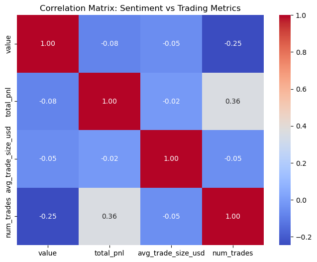

```python
import pandas as pd
import matplotlib.pyplot as plt
import seaborn as sns

# ---- Merge datasets on date ----
# Convert sentiment date to datetime (just date)
sentiment_data['date'] = pd.to_datetime(sentiment_data['date']).dt.date

# Convert trader timestamp to datetime and extract date
trader_data['Timestamp IST'] = pd.to_datetime(
    trader_data['Timestamp IST'], format="%d-%m-%Y %H:%M", errors="coerce"
)
trader_data['date'] = trader_data['Timestamp IST'].dt.date

# Aggregate trader data by day
daily_trader = trader_data.groupby('date').agg(
    total_pnl=('Closed PnL', 'sum'),
    avg_trade_size_usd=('Size USD', 'mean'),
    num_trades=('Account', 'count')
).reset_index()

# Merge with sentiment data
merged_data = pd.merge(sentiment_data, daily_trader, on='date', how='inner')

# ---- Correlation Matrix ----
correlation_matrix = merged_data[['value', 'total_pnl', 'avg_trade_size_usd', 'num_trades']].corr()

print("Correlation matrix between sentiment value, PnL, trade size, and number of trades:")
print(correlation_matrix)

# ---- Heatmap ----
plt.figure(figsize=(8,6))
sns.heatmap(correlation_matrix, annot=True, cmap="coolwarm", fmt=".2f")
plt.title("Correlation Matrix: Sentiment vs Trading Metrics")
plt.show()
```

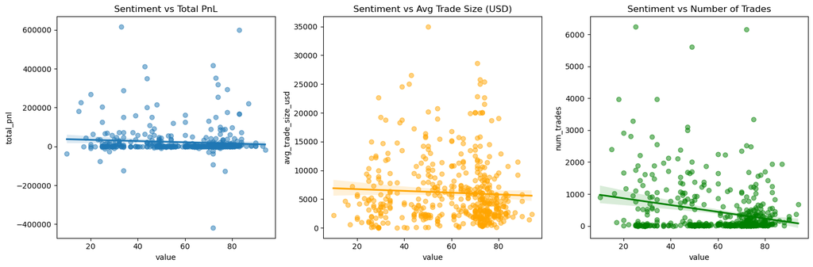

```python
# ---- Regression Plots ----
plt.figure(figsize=(15, 5))

# 1. Sentiment vs PnL
plt.subplot(1, 3, 1)
sns.regplot(x='value', y='total_pnl', data=merged_data, scatter_kws={'alpha':0.5})
plt.title("Sentiment vs Total PnL")

# 2. Sentiment vs Avg Trade Size
plt.subplot(1, 3, 2)
sns.regplot(x='value', y='avg_trade_size_usd', data=merged_data, scatter_kws={'alpha':0.5}, color='orange')
plt.title("Sentiment vs Avg Trade Size (USD)")

# 3. Sentiment vs Number of Trades
plt.subplot(1, 3, 3)
sns.regplot(x='value', y='num_trades', data=merged_data, scatter_kws={'alpha':0.5}, color='green')
plt.title("Sentiment vs Number of Trades")

plt.tight_layout()
plt.show()
```

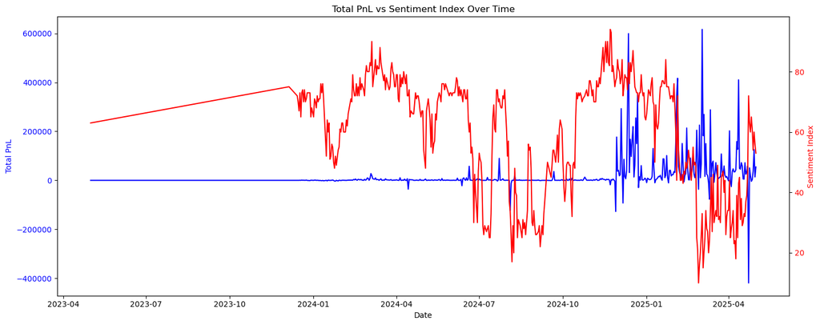

```python
# ---- Time-Series Overlay: Sentiment vs Total PnL ----
fig, ax1 = plt.subplots(figsize=(15,6))

# Plot Total PnL
ax1.plot(merged_data['date'], merged_data['total_pnl'], color='blue', label='Total PnL')
ax1.set_xlabel("Date")
ax1.set_ylabel("Total PnL", color='blue')
ax1.tick_params(axis='y', labelcolor='blue')

# Create second y-axis for sentiment
ax2 = ax1.twinx()
ax2.plot(merged_data['date'], merged_data['value'], color='red', label='Sentiment Index')
ax2.set_ylabel("Sentiment Index", color='red')
ax2.tick_params(axis='y', labelcolor='red')

# Title and Legends
plt.title("Total PnL vs Sentiment Index Over Time")
fig.tight_layout()
plt.show()
```

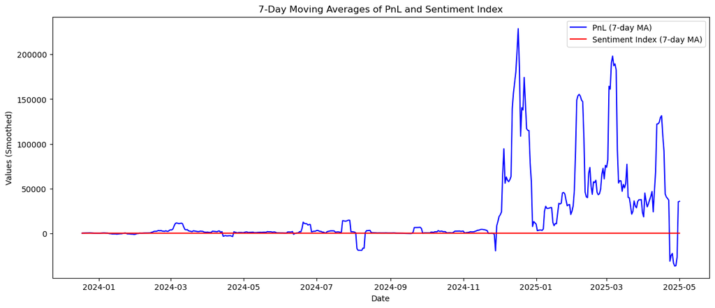

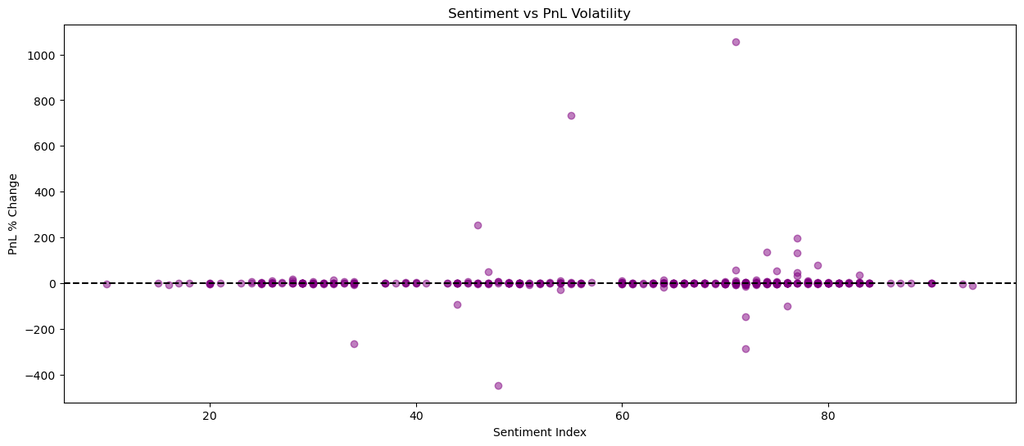

```python
# ---- Rolling Averages (7-day) ----
merged_data['pnl_ma7'] = merged_data['total_pnl'].rolling(window=7).mean()
merged_data['sentiment_ma7'] = merged_data['value'].rolling(window=7).mean()

plt.figure(figsize=(15,6))
plt.plot(merged_data['date'], merged_data['pnl_ma7'], label='PnL (7-day MA)', color='blue')
plt.plot(merged_data['date'], merged_data['sentiment_ma7'], label='Sentiment Index (7-day MA)', color='red')
plt.title("7-Day Moving Averages of PnL and Sentiment Index")
plt.xlabel("Date")
plt.ylabel("Values (Smoothed)")
plt.legend()
plt.show()


# ---- Volatility Analysis ----
# Calculate daily % change for PnL
merged_data['pnl_pct_change'] = merged_data['total_pnl'].pct_change()

plt.figure(figsize=(15,6))
plt.scatter(merged_data['value'], merged_data['pnl_pct_change'], alpha=0.5, c='purple')
plt.axhline(0, color='black', linestyle='--')
plt.title("Sentiment vs PnL Volatility")
plt.xlabel("Sentiment Index")
plt.ylabel("PnL % Change")
plt.show()
```

```python
print("Columns in merged dataset:")
print(merged.columns)
print(merged.head())
```

```
Columns in merged dataset:
Index(['date', 'closed_pnl', 'execution_price', 'num_trades', 'timestamp',
       'value', 'classification'],
      dtype='object')
Empty DataFrame
Columns: [date, closed_pnl, execution_price, num_trades, timestamp, value, classification]
Index: []
```

```python
import pandas as pd

# Load datasets
trader_data = pd.read_csv("historical_data.csv")
sentiment_data = pd.read_csv("fear_greed_index.csv")

# --- Convert timestamps properly ---
# Trader data
if 'Timestamp IST' in trader_data.columns:
    trader_data['date'] = pd.to_datetime(trader_data['Timestamp IST'], dayfirst=True, errors="coerce").dt.date
elif 'timestamp' in trader_data.columns:
    trader_data['date'] = pd.to_datetime(trader_data['timestamp'], dayfirst=True, errors="coerce").dt.date

# Sentiment data (mixed formats)
if 'date' in sentiment_data.columns:
    sentiment_data['date'] = pd.to_datetime(sentiment_data['date'], format="mixed", dayfirst=True, errors="coerce").dt.date
elif 'timestamp' in sentiment_data.columns:
    sentiment_data['date'] = pd.to_datetime(sentiment_data['timestamp'], format="mixed", dayfirst=True, errors="coerce").dt.date

# --- Aggregate trader data by date ---
daily_trader = trader_data.groupby('date').agg({
    'Closed PnL': 'sum',
    'Execution Price': 'mean',
    'Account': 'count'   # number of trades
}).reset_index().rename(columns={'Account': 'num_trades',
                                 'Closed PnL': 'closed_pnl',
                                 'Execution Price': 'execution_price'})

# --- Keep sentiment data daily values ---
daily_sentiment = sentiment_data[['date', 'value', 'classification']]

# --- Merge trader & sentiment data ---
merged = pd.merge(daily_trader, daily_sentiment, on='date', how='inner')

# --- Save merged dataset ---
merged.to_csv("merged_dataset.csv", index=False)

# Show output
print("✅ Merged dataset created with shape:", merged.shape)
print(merged.head())
```

```
✅ Merged dataset created with shape: (479, 6)
         date  closed_pnl  execution_price  num_trades  value classification
0  2023-05-01    0.000000      1898.133333           3     63          Greed
1  2023-12-05    0.000000     11038.300000           9     75  Extreme Greed
2  2023-12-14 -205.434737      8031.868818          11     72          Greed
3  2023-12-15  -24.632034         2.982000           2     70          Greed
4  2023-12-16    0.000000         0.384707           3     67          Greed
```

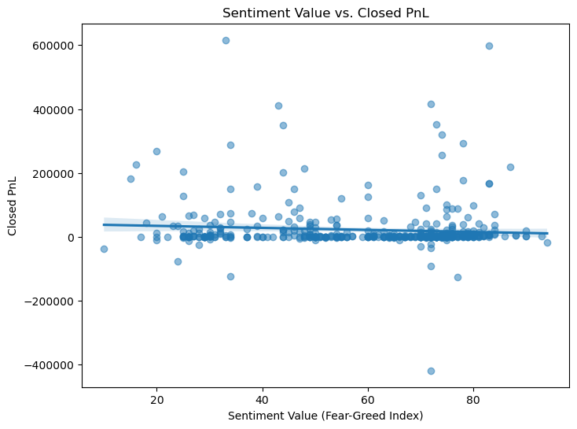

```python
import matplotlib.pyplot as plt
import seaborn as sns

# Scatter + regression line
plt.figure(figsize=(8,6))
sns.regplot(data=merged, x="value", y="closed_pnl", scatter_kws={'alpha':0.5})
plt.title("Sentiment Value vs. Closed PnL")
plt.xlabel("Sentiment Value (Fear-Greed Index)")
plt.ylabel("Closed PnL")
plt.show()
```

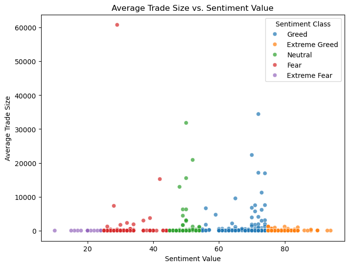

```python
merged["avg_trade_size"] = merged["execution_price"] / merged["num_trades"]

plt.figure(figsize=(8,6))
sns.scatterplot(data=merged, x="value", y="avg_trade_size", hue="classification", alpha=0.7)
plt.title("Average Trade Size vs. Sentiment Value")
plt.xlabel("Sentiment Value")
plt.ylabel("Average Trade Size")
plt.legend(title="Sentiment Class")
plt.show()
```

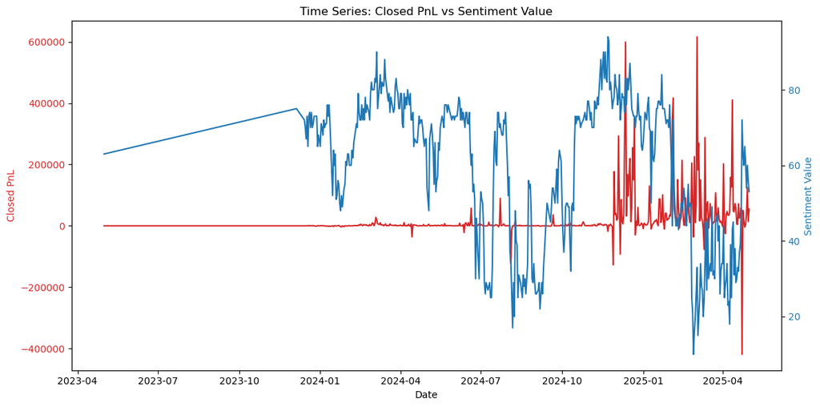

```python
fig, ax1 = plt.subplots(figsize=(12,6))

ax1.set_xlabel("Date")
ax1.set_ylabel("Closed PnL", color="tab:red")
ax1.plot(merged["date"], merged["closed_pnl"], color="tab:red", label="Closed PnL")
ax1.tick_params(axis="y", labelcolor="tab:red")

ax2 = ax1.twinx()
ax2.set_ylabel("Sentiment Value", color="tab:blue")
ax2.plot(merged["date"], merged["value"], color="tab:blue", label="Sentiment Value")
ax2.tick_params(axis="y", labelcolor="tab:blue")

plt.title("Time Series: Closed PnL vs Sentiment Value")
fig.tight_layout()
plt.show()
```

```python
pnl_by_sentiment = merged.groupby("classification")["closed_pnl"].mean()
print("Average PnL per Sentiment Class:\n", pnl_by_sentiment)
```

```
Average PnL per Sentiment Class:
 classification
Extreme Fear     52793.589178
Extreme Greed    23817.292199
Fear             36891.818040
Greed            11140.566181
Neutral          19297.323516
Name: closed_pnl, dtype: float64
```

```python
# Create lagged sentiment columns
merged["sentiment_lag1"] = merged["value"].shift(1)
merged["sentiment_lag2"] = merged["value"].shift(2)

# Correlations with correct column name
corr_same_day = merged["closed_pnl"].corr(merged["value"])
corr_lag1 = merged["closed_pnl"].corr(merged["sentiment_lag1"])
corr_lag2 = merged["closed_pnl"].corr(merged["sentiment_lag2"])

print("Correlation PnL vs Same Day Sentiment:", corr_same_day)
print("Correlation PnL vs Lag 1 Day Sentiment:", corr_lag1)
print("Correlation PnL vs Lag 2 Day Sentiment:", corr_lag2)
```

```
Correlation PnL vs Same Day Sentiment: -0.08264200129021718
Correlation PnL vs Lag 1 Day Sentiment: -0.10777867905603505
Correlation PnL vs Lag 2 Day Sentiment: -0.07650765101963064
```

```python
corr_num_trades = merged["num_trades"].corr(merged["value"])
corr_avg_trade_size = merged["avg_trade_size"].corr(merged["value"])

print("Correlation between Sentiment and Num Trades:", corr_num_trades)
print("Correlation between Sentiment and Avg Trade Size:", corr_avg_trade_size)
```

```
Correlation between Sentiment and Num Trades: -0.24524140464293376
Correlation between Sentiment and Avg Trade Size: -0.04592462959147649
```

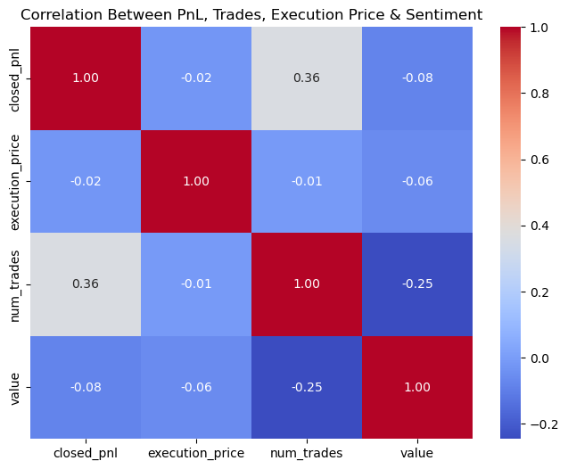

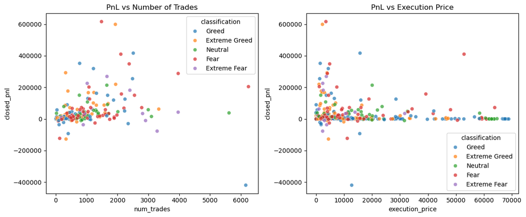

```python
import matplotlib.pyplot as plt
import seaborn as sns

# Correlation heatmap of numeric columns
plt.figure(figsize=(8,6))
sns.heatmap(merged[["closed_pnl", "execution_price", "num_trades", "value"]].corr(),
            annot=True, cmap="coolwarm", fmt=".2f")
plt.title("Correlation Between PnL, Trades, Execution Price & Sentiment")
plt.show()

# Scatter plots to visualize trade activity vs PnL
plt.figure(figsize=(12,5))

plt.subplot(1,2,1)
sns.scatterplot(data=merged, x="num_trades", y="closed_pnl", hue="classification", alpha=0.7)
plt.title("PnL vs Number of Trades")

plt.subplot(1,2,2)
sns.scatterplot(data=merged, x="execution_price", y="closed_pnl", hue="classification", alpha=0.7)
plt.title("PnL vs Execution Price")

plt.tight_layout()
plt.show()
```

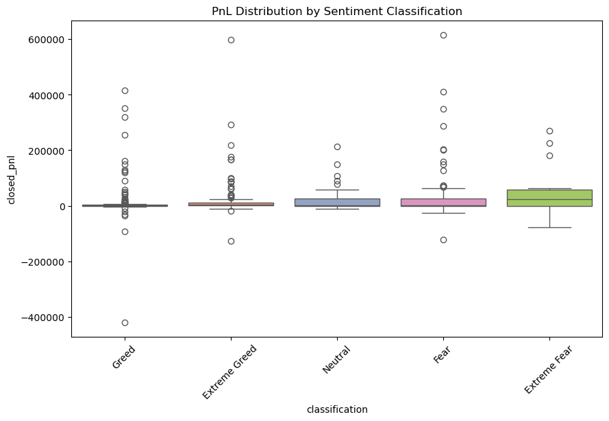

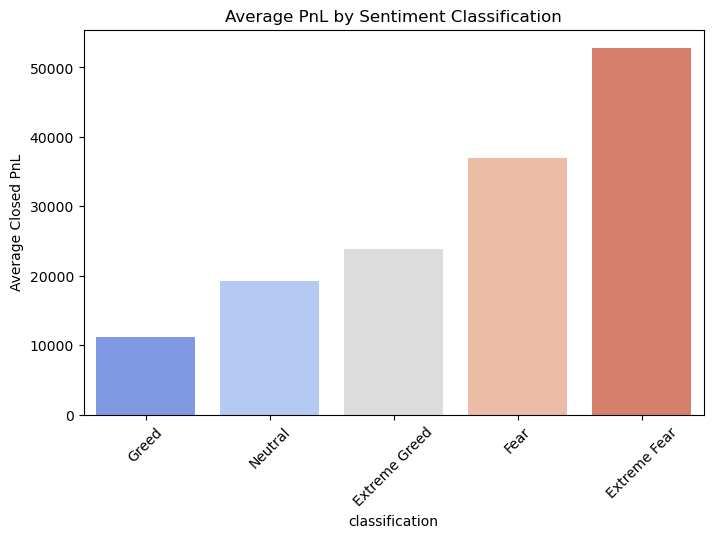

```python
import matplotlib.pyplot as plt
import seaborn as sns

# Boxplot of PnL grouped by sentiment classification
plt.figure(figsize=(10,6))
sns.boxplot(data=merged, x="classification", y="closed_pnl", palette="Set2")
plt.title("PnL Distribution by Sentiment Classification")
plt.xticks(rotation=45)
plt.show()

# Average PnL for each sentiment classification
avg_pnl = merged.groupby("classification")["closed_pnl"].mean().sort_values()

plt.figure(figsize=(8,5))
sns.barplot(x=avg_pnl.index, y=avg_pnl.values, palette="coolwarm")
plt.title("Average PnL by Sentiment Classification")
plt.ylabel("Average Closed PnL")
plt.xticks(rotation=45)
plt.show()
```

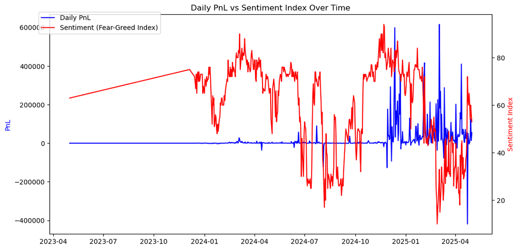

```python
# Convert date column to datetime (if not already)
merged["date"] = pd.to_datetime(merged["date"])

# Aggregate daily PnL
daily_pnl = merged.groupby("date")["closed_pnl"].sum()

# Daily average sentiment value
daily_sentiment = merged.groupby("date")["value"].mean()

# Plotting
fig, ax1 = plt.subplots(figsize=(12,6))

# PnL Trend
ax1.plot(daily_pnl.index, daily_pnl.values, color="blue", label="Daily PnL")
ax1.set_ylabel("PnL", color="blue")

# Secondary y-axis for sentiment
ax2 = ax1.twinx()
ax2.plot(daily_sentiment.index, daily_sentiment.values, color="red", label="Sentiment (Fear-Greed Index)")
ax2.set_ylabel("Sentiment Index", color="red")

plt.title("Daily PnL vs Sentiment Index Over Time")
fig.legend(loc="upper left", bbox_to_anchor=(0.1,0.9))
plt.show()
```

[figure not shown]

```
Correlation between sentiment and volatility: nan
```

```python
# Calculate daily returns from execution_price
merged["execution_price"] = pd.to_numeric(merged["execution_price"], errors="coerce")
merged = merged.dropna(subset=["execution_price"])

merged["date"] = pd.to_datetime(merged["date"])
merged = merged.sort_values("date")

# Calculate returns and volatility
merged["returns"] = merged["execution_price"].pct_change()
daily_volatility = merged.groupby("date")["returns"].std()

# Match with sentiment
daily_sentiment = merged.groupby("date")["value"].mean()

# Combine
volatility_sentiment = pd.DataFrame({
    "volatility": daily_volatility,
    "sentiment": daily_sentiment
}).dropna()

# Scatter plot
plt.figure(figsize=(8,6))
sns.scatterplot(x=volatility_sentiment["sentiment"],
                y=volatility_sentiment["volatility"])
plt.xlabel("Sentiment (Fear-Greed Index)")
plt.ylabel("Daily Volatility")
plt.title("Market Volatility vs Sentiment")
plt.show()

# Correlation
correlation = volatility_sentiment["sentiment"].corr(volatility_sentiment["volatility"])
print("Correlation between sentiment and volatility:", correlation)
```

```python
print(model_data.columns)
```

```
Index(['date', 'closed_pnl', 'execution_price', 'num_trades', 'value',
       'classification', 'avg_trade_size', 'sentiment_lag1', 'sentiment_lag2',
       'returns', 'volatility'],
      dtype='object')
```

```python
print("Shape before dropping NA:", merged.shape)

model_data = merged.copy()
model_data["volatility"] = model_data.groupby("date")["returns"].transform("std")

# Keep only rows with no missing values
model_data = model_data.dropna(subset=["closed_pnl", "volatility", "value", "avg_trade_size", "num_trades"])
print("Shape after dropping NA:", model_data.shape)

print(model_data.head())
```

```
Shape before dropping NA: (479, 10)
Shape after dropping NA: (0, 11)
Empty DataFrame
Columns: [date, closed_pnl, execution_price, num_trades, value, classification, avg_trade_size, sentiment_lag1, sentiment_lag2, returns, volatility]
Index: []
```

```python
model_data["volatility"] = model_data["volatility"].fillna(0)
```

```python
model_data = model_data.dropna(subset=["closed_pnl", "value"])
model_data["volatility"] = model_data["volatility"].fillna(0)
```

```python
print(model_data.isna().sum())
```

```
date               0
closed_pnl         0
execution_price    0
num_trades         0
value              0
classification     0
avg_trade_size     0
sentiment_lag1     0
sentiment_lag2     0
returns            0
volatility         0
dtype: int64
```

```python
# Drop rows only if closed_pnl or value is missing
model_data = model_data.dropna(subset=["closed_pnl", "value"])

# Replace NaN in volatility and returns with 0
model_data["volatility"] = model_data["volatility"].fillna(0)
model_data["returns"] = model_data["returns"].fillna(0)
```

```python
print("X shape:", X.shape)
print("y shape:", y.shape)
print("Number of NaNs in X:\n", X.isna().sum())
print("Number of NaNs in y:", y.isna().sum())
```

```
X shape: (0, 8)
y shape: (0,)
Number of NaNs in X:
 execution_price    0
num_trades         0
value              0
avg_trade_size     0
sentiment_lag1     0
sentiment_lag2     0
returns            0
volatility         0
dtype: int64
Number of NaNs in y: 0
```

```python
print("model_data shape:", model_data.shape)
print("Columns in model_data:", model_data.columns.tolist())
print("First 10 rows of model_data:\n", model_data.head(10))
```

```
model_data shape: (0, 11)
Columns in model_data: ['date', 'closed_pnl', 'execution_price', 'num_trades', 'value', 'classification', 'avg_trade_size', 'sentiment_lag1', 'sentiment_lag2', 'returns', 'volatility']
First 10 rows of model_data:
 Empty DataFrame
Columns: [date, closed_pnl, execution_price, num_trades, value, classification, avg_trade_size, sentiment_lag1, sentiment_lag2, returns, volatility]
Index: []
```

```python
# Clean column names (remove leading/trailing spaces)
merged.columns = merged.columns.str.strip()

# List of columns you want to check for NaNs
cols_to_check = ['returns', 'volatility', 'sentiment_lag1', 'sentiment_lag2']

# Keep only the columns that exist in the DataFrame
existing_cols = [c for c in cols_to_check if c in merged.columns]

# Drop rows with NaNs in those existing columns
model_data = merged.dropna(subset=existing_cols)

# Check the result
print("Columns in merged DataFrame:", merged.columns.tolist())
print("Columns used for dropping NaNs:", existing_cols)
print("Shape after selective drop:", model_data.shape)
print("Remaining NaNs:\n", model_data.isna().sum())
```

```
Columns in merged DataFrame: ['date', 'closed_pnl', 'execution_price', 'num_trades', 'value', 'classification', 'avg_trade_size', 'sentiment_lag1', 'sentiment_lag2', 'returns']
Columns used for dropping NaNs: ['returns', 'sentiment_lag1', 'sentiment_lag2']
Shape after selective drop: (477, 10)
Remaining NaNs:
 date               0
closed_pnl         0
execution_price    0
num_trades         0
value              0
classification     0
avg_trade_size     0
sentiment_lag1     0
sentiment_lag2     0
returns            0
dtype: int64
```

```python
# -------------------------------
# Step 1: Feature selection
# -------------------------------
X = model_data[['execution_price', 'num_trades', 'value', 'avg_trade_size',
                'sentiment_lag1', 'sentiment_lag2', 'returns']]  # Input features
y = model_data['classification']  # Target variable

# -------------------------------
# Step 2: Split data into training and test sets
# -------------------------------
from sklearn.model_selection import train_test_split

X_train, X_test, y_train, y_test = train_test_split(
    X, y, test_size=0.2, random_state=42
)
print("Training set shape:", X_train.shape)
print("Test set shape:", X_test.shape)

# -------------------------------
# Step 3: Scale features
# -------------------------------
from sklearn.preprocessing import StandardScaler

scaler = StandardScaler()
X_train_scaled = scaler.fit_transform(X_train)
X_test_scaled = scaler.transform(X_test)

# -------------------------------
# Step 4: Train Random Forest Classifier
# -------------------------------
from sklearn.ensemble import RandomForestClassifier
from sklearn.metrics import classification_report, confusion_matrix

model = RandomForestClassifier(random_state=42)
model.fit(X_train_scaled, y_train)

# -------------------------------
# Step 5: Make predictions and evaluate
# -------------------------------
y_pred = model.predict(X_test_scaled)

print("Confusion Matrix:\n", confusion_matrix(y_test, y_pred))
print("\nClassification Report:\n", classification_report(y_test, y_pred))
```

```
Training set shape: (381, 7)
Test set shape: (96, 7)
Confusion Matrix:
 [[ 2  0  1  0  0]
 [ 0 24  0  0  0]
 [ 0  0 16  0  0]
 [ 0  0  0 39  0]
 [ 0  0  0  0 14]]

Classification Report:
                precision    recall  f1-score   support

 Extreme Fear       1.00      0.67      0.80         3
Extreme Greed       1.00      1.00      1.00        24
         Fear       0.94      1.00      0.97        16
        Greed       1.00      1.00      1.00        39
      Neutral       1.00      1.00      1.00        14

     accuracy                           0.99        96
    macro avg       0.99      0.93      0.95        96
 weighted avg       0.99      0.99      0.99        96
```

```
Training set shape: (381, 7)
Test set shape: (96, 7)
Confusion Matrix:
 [[ 2  0  1  0  0]
 [ 0 24  0  0  0]
 [ 0  0 16  0  0]
 [ 0  0  0 39  0]
 [ 0  0  0  0 14]]

Classification Report:
                precision    recall  f1-score   support

 Extreme Fear       1.00      0.67      0.80         3
Extreme Greed       1.00      1.00      1.00        24
         Fear       0.94      1.00      0.97        16
        Greed       1.00      1.00      1.00        39
      Neutral       1.00      1.00      1.00        14

     accuracy                           0.99        96
    macro avg       0.99      0.93      0.95        96
 weighted avg       0.99      0.99      0.99        96

Test Accuracy: 0.9895833333333334
```

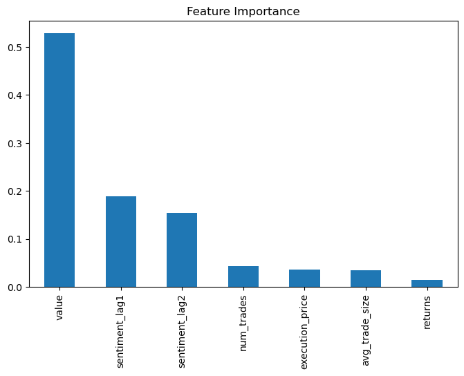

```
Best parameters: {'max_depth': None, 'min_samples_leaf': 1, 'min_samples_split': 2, 'n_estimators': 100}
Best training score: 0.9684552289815448
Test Accuracy with Best Model: 0.9895833333333334
Model saved successfully!
```

```python
# -------------------------------
# Step 1: Feature selection
# -------------------------------
X = model_data[['execution_price', 'num_trades', 'value', 'avg_trade_size',
                'sentiment_lag1', 'sentiment_lag2', 'returns']]  # Input features
y = model_data['classification']  # Target variable

# -------------------------------
# Step 2: Split data into training and test sets
# -------------------------------
from sklearn.model_selection import train_test_split

X_train, X_test, y_train, y_test = train_test_split(
    X, y, test_size=0.2, random_state=42
)
print("Training set shape:", X_train.shape)
print("Test set shape:", X_test.shape)

# -------------------------------
# Step 3: Scale features
# -------------------------------
from sklearn.preprocessing import StandardScaler

scaler = StandardScaler()
X_train_scaled = scaler.fit_transform(X_train)
X_test_scaled = scaler.transform(X_test)

# -------------------------------
# Step 4: Train Random Forest Classifier
# -------------------------------
from sklearn.ensemble import RandomForestClassifier
from sklearn.metrics import classification_report, confusion_matrix, accuracy_score

model = RandomForestClassifier(random_state=42)
model.fit(X_train_scaled, y_train)

y_pred = model.predict(X_test_scaled)

print("Confusion Matrix:\n", confusion_matrix(y_test, y_pred))
print("\nClassification Report:\n", classification_report(y_test, y_pred))
print("Test Accuracy:", accuracy_score(y_test, y_pred))

# -------------------------------
# Step 5: Feature Importance
# -------------------------------
import pandas as pd
import matplotlib.pyplot as plt

feature_importances = pd.Series(model.feature_importances_, index=X.columns)
feature_importances.sort_values(ascending=False).plot(kind='bar', figsize=(8,5))
plt.title("Feature Importance")
plt.show()

# -------------------------------
# Step 6: Hyperparameter Tuning with GridSearchCV
# -------------------------------
from sklearn.model_selection import GridSearchCV

param_grid = {
    'n_estimators': [100, 200],
    'max_depth': [None, 5, 10],
    'min_samples_split': [2, 5],
    'min_samples_leaf': [1, 2]
}

grid_search = GridSearchCV(RandomForestClassifier(random_state=42),
                           param_grid, cv=5, scoring='accuracy')
grid_search.fit(X_train_scaled, y_train)

print("Best parameters:", grid_search.best_params_)
print("Best training score:", grid_search.best_score_)

# -------------------------------
# Step 7: Evaluate best model on test set
# -------------------------------
best_model = grid_search.best_estimator_
y_pred_best = best_model.predict(X_test_scaled)
print("Test Accuracy with Best Model:", accuracy_score(y_test, y_pred_best))

# -------------------------------
# Step 8: Save the trained model
# -------------------------------
import joblib
joblib.dump(best_model, 'random_forest_model.pkl')
print("Model saved successfully!")
```

```
Columns used for dropping NaNs: ['returns', 'sentiment_lag1', 'sentiment_lag2']
Shape after selective drop: (477, 10)
Training set shape: (381, 7)
Test set shape: (96, 7)
Confusion Matrix:
 [[ 2  0  1  0  0]
 [ 0 24  0  0  0]
 [ 0  0 16  0  0]
 [ 0  0  0 39  0]
 [ 0  0  0  0 14]]

Classification Report:
                precision    recall  f1-score   support

 Extreme Fear       1.00      0.67      0.80         3
Extreme Greed       1.00      1.00      1.00        24
         Fear       0.94      1.00      0.97        16
        Greed       1.00      1.00      1.00        39
      Neutral       1.00      1.00      1.00        14

     accuracy                           0.99        96
    macro avg       0.99      0.93      0.95        96
 weighted avg       0.99      0.99      0.99        96

Test Accuracy: 0.9895833333333334
```

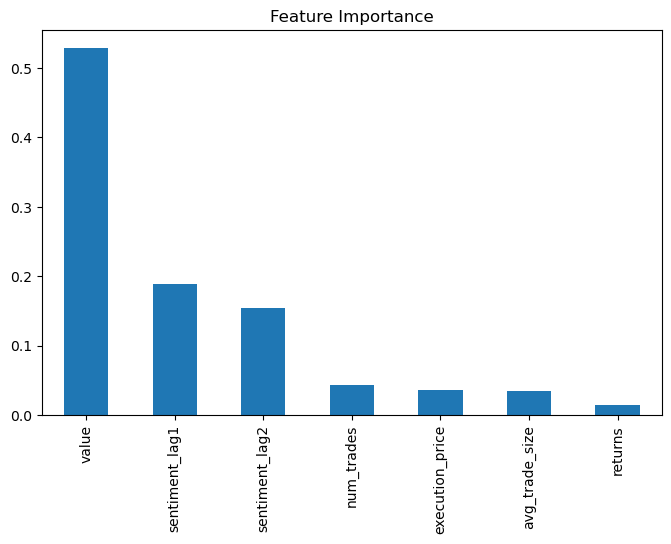

```
Best parameters: {'max_depth': None, 'min_samples_leaf': 1, 'min_samples_split': 2, 'n_estimators': 100}
Best training score: 0.9684552289815448
Test Accuracy with Best Model: 0.9895833333333334
Model saved successfully!
Model loaded successfully!
Predictions for new data: ['Extreme Greed' 'Extreme Greed']
Prediction probabilities:
 [[0.06 0.33 0.15 0.24 0.22]
 [0.06 0.33 0.14 0.27 0.2 ]]
```

```python
# -------------------------------
# Step 0: Clean columns and drop NaNs
# -------------------------------
merged.columns = merged.columns.str.strip()  # remove extra spaces
cols_to_check = ['returns', 'volatility', 'sentiment_lag1', 'sentiment_lag2']
existing_cols = [c for c in cols_to_check if c in merged.columns]
model_data = merged.dropna(subset=existing_cols)
print("Columns used for dropping NaNs:", existing_cols)
print("Shape after selective drop:", model_data.shape)

# -------------------------------
# Step 1: Feature selection
# -------------------------------
X = model_data[['execution_price', 'num_trades', 'value', 'avg_trade_size',
                'sentiment_lag1', 'sentiment_lag2', 'returns']]  # Input features
y = model_data['classification']  # Target variable

# -------------------------------
# Step 2: Split data into training and test sets
# -------------------------------
from sklearn.model_selection import train_test_split

X_train, X_test, y_train, y_test = train_test_split(
    X, y, test_size=0.2, random_state=42
)
print("Training set shape:", X_train.shape)
print("Test set shape:", X_test.shape)

# -------------------------------
# Step 3: Scale features
# -------------------------------
from sklearn.preprocessing import StandardScaler

scaler = StandardScaler()
X_train_scaled = scaler.fit_transform(X_train)
X_test_scaled = scaler.transform(X_test)

# -------------------------------
# Step 4: Train Random Forest Classifier
# -------------------------------
from sklearn.ensemble import RandomForestClassifier
from sklearn.metrics import classification_report, confusion_matrix, accuracy_score

model = RandomForestClassifier(random_state=42)
model.fit(X_train_scaled, y_train)

y_pred = model.predict(X_test_scaled)

print("Confusion Matrix:\n", confusion_matrix(y_test, y_pred))
print("\nClassification Report:\n", classification_report(y_test, y_pred))
print("Test Accuracy:", accuracy_score(y_test, y_pred))

# -------------------------------
# Step 5: Feature Importance
# -------------------------------
import pandas as pd
import matplotlib.pyplot as plt

feature_importances = pd.Series(model.feature_importances_, index=X.columns)
feature_importances.sort_values(ascending=False).plot(kind='bar', figsize=(8,5))
plt.title("Feature Importance")
plt.show()

# -------------------------------
# Step 6: Hyperparameter Tuning with GridSearchCV
# -------------------------------
from sklearn.model_selection import GridSearchCV

param_grid = {
    'n_estimators': [100, 200],
    'max_depth': [None, 5, 10],
    'min_samples_split': [2, 5],
    'min_samples_leaf': [1, 2]
}

grid_search = GridSearchCV(RandomForestClassifier(random_state=42),
                           param_grid, cv=5, scoring='accuracy')
grid_search.fit(X_train_scaled, y_train)

print("Best parameters:", grid_search.best_params_)
print("Best training score:", grid_search.best_score_)

# -------------------------------
# Step 7: Evaluate best model on test set
# -------------------------------
best_model = grid_search.best_estimator_
y_pred_best = best_model.predict(X_test_scaled)
print("Test Accuracy with Best Model:", accuracy_score(y_test, y_pred_best))

# -------------------------------
# Step 8: Save the trained model
# -------------------------------
import joblib
joblib.dump(best_model, 'random_forest_model.pkl')
print("Model saved successfully!")

# -------------------------------
# Step 9: Load model and make predictions on new data
# -------------------------------
best_model_loaded = joblib.load('random_forest_model.pkl')
print("Model loaded successfully!")

# Example new data
new_data = pd.DataFrame({
    'execution_price': [50000, 48000],
    'num_trades': [10, 5],
    'value': [100000, 50000],
    'avg_trade_size': [10000, 10000],
    'sentiment_lag1': [0.2, -0.1],
    'sentiment_lag2': [0.1, 0.0],
    'returns': [0.02, -0.01]
})

# Scale new data
new_data_scaled = scaler.transform(new_data)

# Make predictions
predictions = best_model_loaded.predict(new_data_scaled)
print("Predictions for new data:", predictions)

# Optional: Prediction probabilities
probabilities = best_model_loaded.predict_proba(new_data_scaled)
print("Prediction probabilities:\n", probabilities)
```

## Code Pipeline

# Step 0: Clean columns and drop NaNs